# A summary of the tweets generated at the 2017 Evolution meeting in Portland, OR

François Michonneau

## About this document

This document was generated using RMarkdown, and the source is available on GitHub at: https://github.com/fmichonneau/evol2017-tweets.

Pull requests to add other figures or fix bugs are welcome.

This document (and associated code) is released under a CC0 licence.

If you have questions or comments, I am on twitter at fmic_ or by email at francois.michonneau@gmail.com

## Basic summary

- Total number of tweets with the #Evol2017 hashtag between 2017-06-15 12:50:58, and 2017-06-28 23:59:42: 9885
- Total of original tweets (no retweets): 4238.
- Number of users who tweeted: 2208.

## The 5 most favorited tweets

> I’m still agog at the cleverness of this #evol2017 poster: flaps reveal the math literally under the hood. Anyone k… https://t.co/CmUGUULppZ

> — tjvision | [2017-06-28](https://twitter.com/tjvision/status/879907207730659328) | 132 retweets, 485 favorites.

> “One tree to rule them all; one model to bind them. One algorithm to search them all, and in the tree space find th… https://t.co/kAL4eCg54d

> — HiBiologist | [2017-06-26](https://twitter.com/HiBiologist/status/879134807480913920) | 268 retweets, 474 favorites.

> Turns out the Green Arrow (@StephenAmell) is here at #Evol2017 conf and ready to fight Intelligent Design– thanks… https://t.co/CKKSb6NcZt

> — mafnoor | [2017-06-24](https://twitter.com/mafnoor/status/878743924474380288) | 79 retweets, 426 favorites.

> As a woman and a mom, I beg that we stop with the science cliche that some things are “simple enough to explain to your mom” #evol2017

> — HollyDunsworth | [2017-06-24](https://twitter.com/HollyDunsworth/status/878725760835399681) | 101 retweets, 302 favorites.

> States eliminated from future Evolution meetings due to discrimination laws:

> North Carolina Tennessee Kansas Mississippi Texas

> #evol2017 — LAevolving | [2017-06-23](https://twitter.com/LAevolving/status/878384138721476609) | 120 retweets, 214 favorites.

## The 5 most retweeted tweets

> “One tree to rule them all; one model to bind them. One algorithm to search them all, and in the tree space find th… https://t.co/kAL4eCg54d

> — HiBiologist | [2017-06-26](https://twitter.com/HiBiologist/status/879134807480913920) | 268 retweets, 474 favorites.

> Two faculty positions in evolution or ecology @ UofToronto. Please RT #evol2017 https://t.co/lZBwlRuxJT

> — aneilagrawal | [2017-06-27](https://twitter.com/aneilagrawal/status/879811895301033984) | 235 retweets, 83 favorites.

> I’m still agog at the cleverness of this #evol2017 poster: flaps reveal the math literally under the hood. Anyone k… https://t.co/CmUGUULppZ

> — tjvision | [2017-06-28](https://twitter.com/tjvision/status/879907207730659328) | 132 retweets, 485 favorites.

> Looking for grad students and postdocs to join my lab at @UTAustin in 2018. Interested? Let’s talk at #evol2017! https://t.co/mz27a4PSto

> — melisabetta | [2017-06-24](https://twitter.com/melisabetta/status/878609631328616448) | 128 retweets, 74 favorites.

> States eliminated from future Evolution meetings due to discrimination laws:

> North Carolina Tennessee Kansas Mississippi Texas

> #evol2017 — LAevolving | [2017-06-23](https://twitter.com/LAevolving/status/878384138721476609) | 120 retweets, 214 favorites.

## Top tweeters

All generated tweets (including retweets)

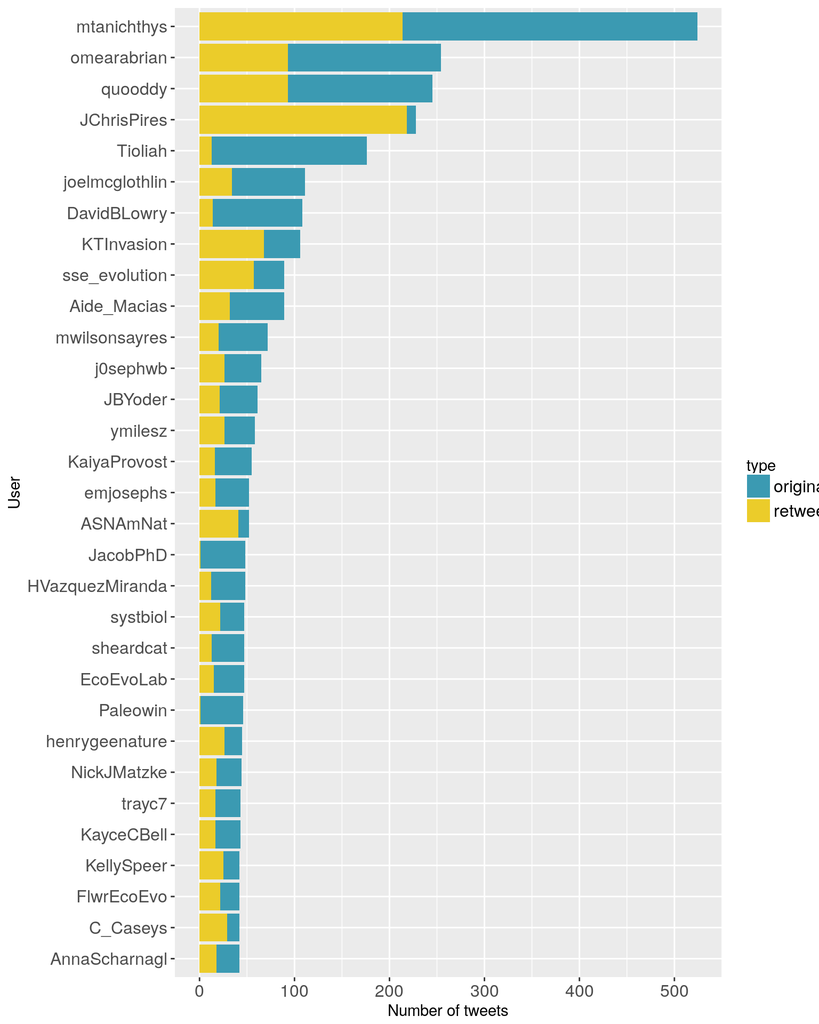

Only for original tweets (retweets excluded)

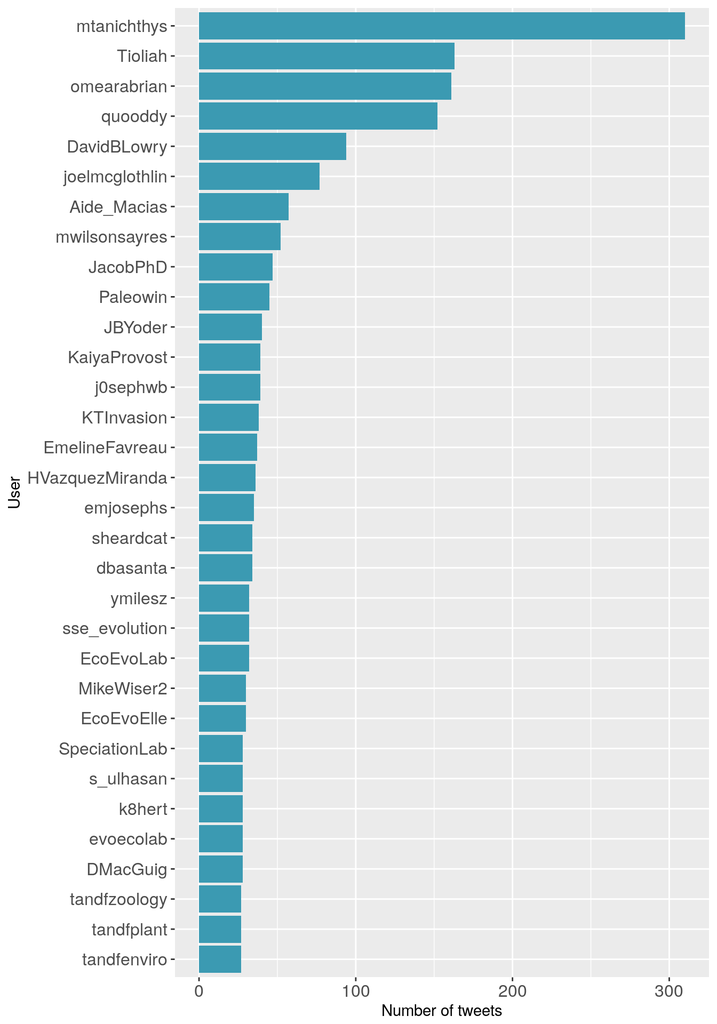

## Most favorited/retweeted users

The figures below only include users who tweeted 5+ times, and don’t include retweets.

### Number of favorites received by users

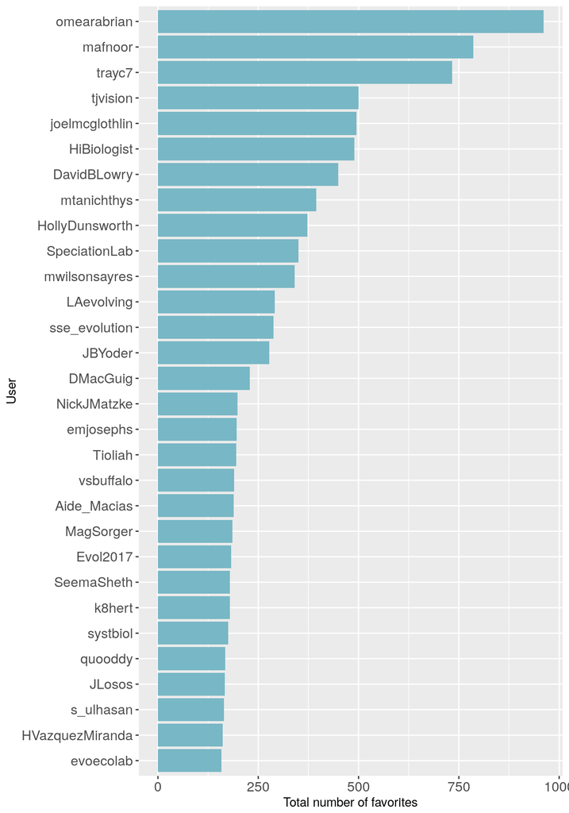

### Number of retweets received by users

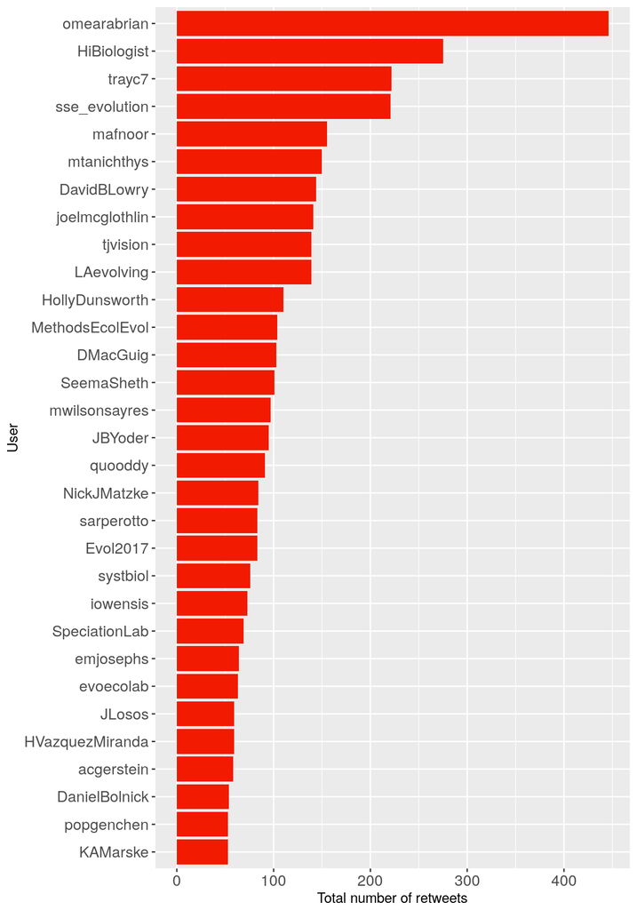

### Mean numbers of favorites received

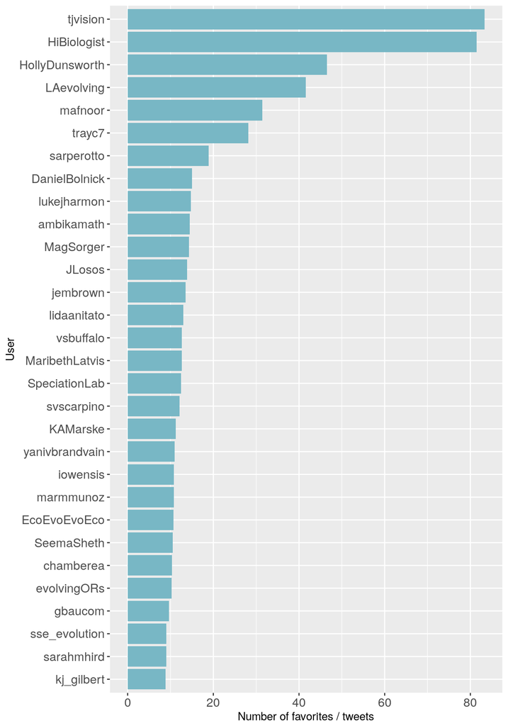

### Mean numbers of retweets received

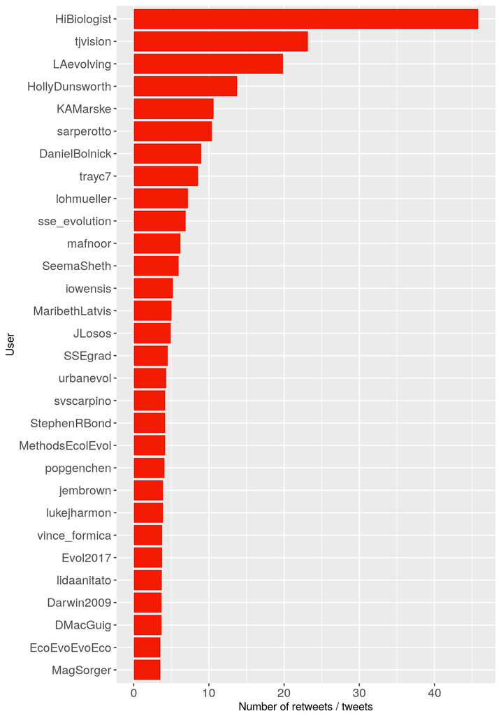

## Word cloud

The top 100 words among the original tweets.

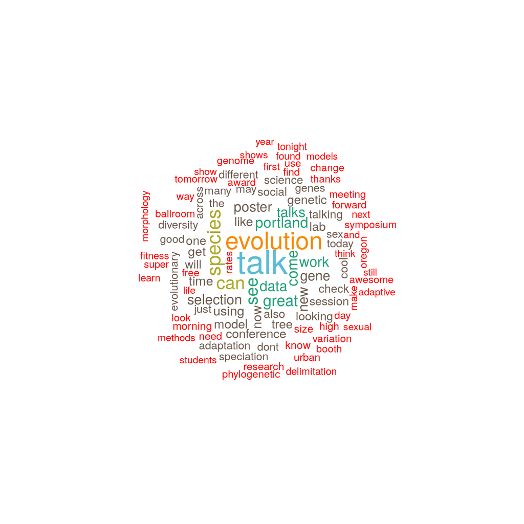

## Most used emojis

[figure not shown]

## Most commonly associated words

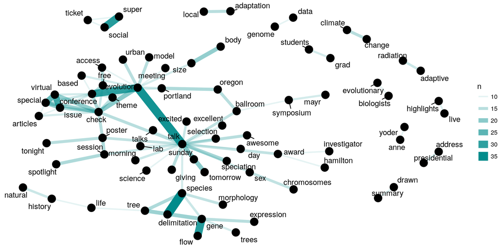

## Sentiment analysis

Very little negativity in the #Evol2017 tweets. Most positive before lunch, and in the evening.

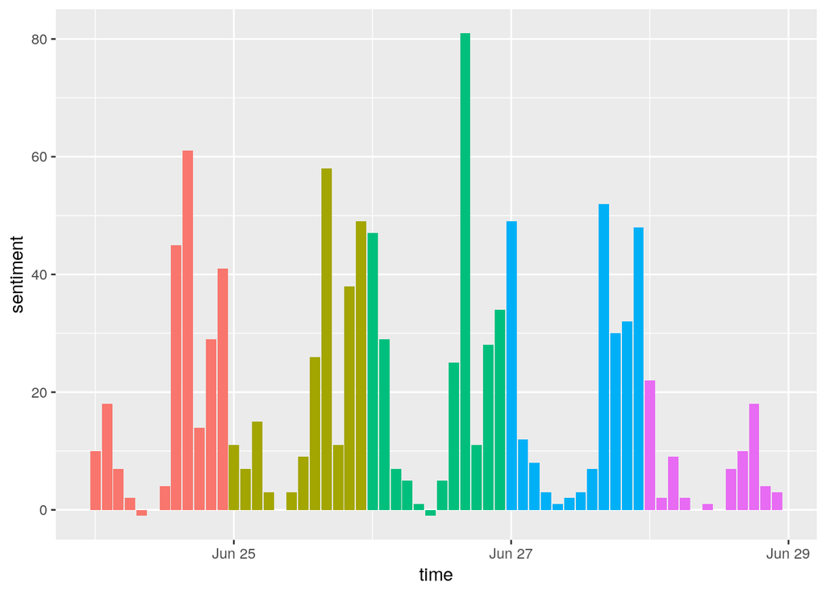

To the extent possible under law, [Francois Michonneau](https://github.com/fmichonneau/evol2017-tweets) has waived all copyright and related or neighboring rights to Summary of tweets at the 2017 Evolution conference. This work is published from: United States.